# Домашнее задание по базовой визуализации данных в R 1.

Sergey

2024-09-28

# Загрузка датасета и первичная обработка

```r
hogwarts <- read_csv("data/hogwarts_2024.csv")
hogwarts |> head()
```

```
## # A tibble: 6 × 60
##      id house    course sex   wandCore bloodStatus result Defence against the …¹
##   <dbl> <chr>     <dbl> <chr> <chr>    <chr>        <dbl>                  <dbl>
## 1     1 Ravencl…      4 fema… unicorn… half-blood      94                     73
## 2     2 Hufflep…      5 male  phoenix… half-blood      33                     38
## 3     3 Ravencl…      4 fema… dragon … half-blood     137                     52
## 4     4 Hufflep…      2 male  phoenix… half-blood      27                     50
## 5     5 Hufflep…      2 fema… phoenix… half-blood      67                     47
## 6     6 Gryffin…      6 male  phoenix… muggle-born    126                     44
## # ℹ abbreviated name: ¹`Defence against the dark arts exam`
## # ℹ 52 more variables: `Flying exam` <dbl>, `Astronomy exam` <dbl>,
## #   `Herbology exam` <dbl>, `Divinations exam` <dbl>, `Charms exam` <dbl>,
## #   `History of magic exam` <dbl>, `Arithmancy exam` <dbl>,
## #   `Care of magical creatures exam` <dbl>, `Muggle studies exam` <dbl>,
## #   `Study of ancient runes exam` <dbl>, `Transfiguration exam` <dbl>,
## #   `Potions exam` <dbl>, week_1 <dbl>, week_2 <dbl>, week_3 <dbl>, …
```

```r
hogwarts |> glimpse()
```

```
## Rows: 560
## Columns: 60
## $ id                                   <dbl> 1, 2, 3, 4, 5, 6, 7, 8, 9, 10, 11…
## $ house                                <chr> "Ravenclaw", "Hufflepuff", "Raven…
## $ course                               <dbl> 4, 5, 4, 2, 2, 6, 7, 5, 2, 3, 7, …
## $ sex                                  <chr> "female", "male", "female", "male…
## $ wandCore                             <chr> "unicorn hair", "phoenix feather"…
## $ bloodStatus                          <chr> "half-blood", "half-blood", "half…
## $ result                               <dbl> 94, 33, 137, 27, 67, 126, 63, 7, …
## $ `Defence against the dark arts exam` <dbl> 73, 38, 52, 50, 47, 44, 51, 47, 2…
## $ `Flying exam`                        <dbl> 33, 36, 73, 42, 41, 52, 34, 34, 2…
## $ `Astronomy exam`                     <dbl> 57, 45, 66, 49, 57, 59, 58, 37, 5…
## $ `Herbology exam`                     <dbl> 73, 50, 62, 39, 38, 46, 59, 23, 2…
## $ `Divinations exam`                   <dbl> 66, 54, 72, 42, 47, 49, 42, 38, 1…
## $ `Charms exam`                        <dbl> 60, 70, 77, 46, 35, 55, 86, 20, 4…
```

[output cut: 47 more lines]

```r
# поменяем тип некотрых данных
hogwarts <- hogwarts |> mutate(
  across(c(house, course, sex, wandCore, bloodStatus), ~ as.factor(.x))
)
hogwarts |> summary()
```

```
##        id               house     course      sex                    wandCore
##  Min.   :  1.0   Gryffindor:126   1: 80   female:333   dragon heartstring:196
##  1st Qu.:140.8   Hufflepuff:179   2:101   male  :227   phoenix feather   :181
##  Median :280.5   Ravenclaw :122   3: 67                unicorn hair      :183
##  Mean   :280.5   Slytherin :133   4: 71
##  3rd Qu.:420.2                    5: 88
##  Max.   :560.0                    6: 67
##                                   7: 86
##       bloodStatus      result        Defence against the dark arts exam
##  half-blood :391   Min.   :-292.00   Min.   : 0
##  muggle-born: 60   1st Qu.:   7.00   1st Qu.:39
##  pure-blood :109   Median :  70.50   Median :49
##                    Mean   :  59.71   Mean   :48
##                    3rd Qu.: 128.25   3rd Qu.:58
##                    Max.   : 260.00   Max.   :89
##
##   Flying exam    Astronomy exam  Herbology exam  Divinations exam
##  Min.   : 0.00   Min.   : 0.00   Min.   : 0.00   Min.   : 0.00
##  1st Qu.:36.00   1st Qu.:37.00   1st Qu.:39.00   1st Qu.:38.00
##  Median :48.00   Median :49.00   Median :49.00   Median :49.00
##  Mean   :47.37   Mean   :47.99   Mean   :47.75   Mean   :48.44
##  3rd Qu.:60.00   3rd Qu.:60.00   3rd Qu.:58.00   3rd Qu.:59.00
##  Max.   :85.00   Max.   :87.00   Max.   :86.00   Max.   :89.00
##
##   Charms exam    History of magic exam Arithmancy exam
##  Min.   : 0.00   Min.   : 0.00         Min.   : 0.00
##  1st Qu.:39.00   1st Qu.:37.00         1st Qu.:38.00
##  Median :49.00   Median :48.00         Median :50.00
##  Mean   :48.36   Mean   :47.28         Mean   :48.38
##  3rd Qu.:59.00   3rd Qu.:58.00         3rd Qu.:60.00
##  Max.   :98.00   Max.   :85.00         Max.   :91.00
##
##  Care of magical creatures exam Muggle studies exam Study of ancient runes exam
##  Min.   : 0.00                  Min.   : 0.00       Min.   : 0.00
##  1st Qu.:38.00                  1st Qu.:38.00       1st Qu.:38.00
##  Median :49.00                  Median :50.00       Median :48.00
##  Mean   :48.11                  Mean   :48.64       Mean   :47.44
##  3rd Qu.:60.00                  3rd Qu.:61.00       3rd Qu.:58.00
##  Max.   :95.00                  Max.   :94.00       Max.   :89.00
##
```

[output cut: 73 more lines]

```
##  Min.   :-20.0   Min.   :-20.000   Min.   :-20.00   Min.   :-20.000
##  1st Qu.: -1.0   1st Qu.: -1.000   1st Qu.: -1.00   1st Qu.: -1.000
##  Median :  1.0   Median :  1.000   Median :  1.00   Median :  1.000
##  Mean   :  1.7   Mean   :  2.079   Mean   :  1.32   Mean   :  1.864
##  3rd Qu.:  5.0   3rd Qu.:  5.000   3rd Qu.:  5.00   3rd Qu.:  5.000
##  Max.   : 20.0   Max.   : 20.000   Max.   : 20.00   Max.   : 20.000
##
##     week_39           week_40
##  Min.   :-20.000   Min.   :-20.000
##  1st Qu.: -1.000   1st Qu.: -3.000
##  Median :  1.000   Median :  0.000
##  Mean   :  1.438   Mean   :  1.079
##  3rd Qu.:  5.000   3rd Qu.:  5.000
##  Max.   : 20.000   Max.   : 20.000
##
```

# Стобчатые диаграммы

## Задание 1

Постройте барплот (столбчатую диаграмму), отражающую распределение числа студентов по курсу обучения. Примените любую из встроенных тем ggplot. Раскрасьте столбики любым понравившимся вам цветом (можно использовать как словесные обозначения, так и гекскоды). Добавьте цветконтура столбиков.

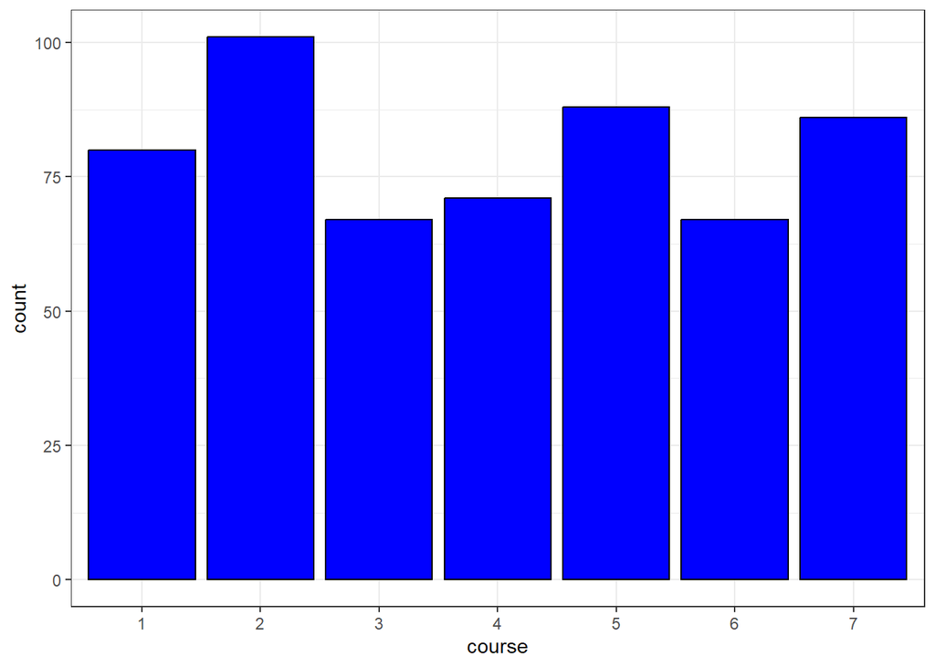

## Задание 2 Создайте новый барплот, отражающий распределение числа студентов по факультету. Добавьте на график вторую факторную переменную – происхождение (bloodStatus). Модифицируйте при помощи аргумента position графика так, чтобы каждый столбец показывал распределение факультета по чистоте крови в долях. Примените произвольную тему.Запишите текстом в rmd-документе, какой вывод можно сделать из графика?

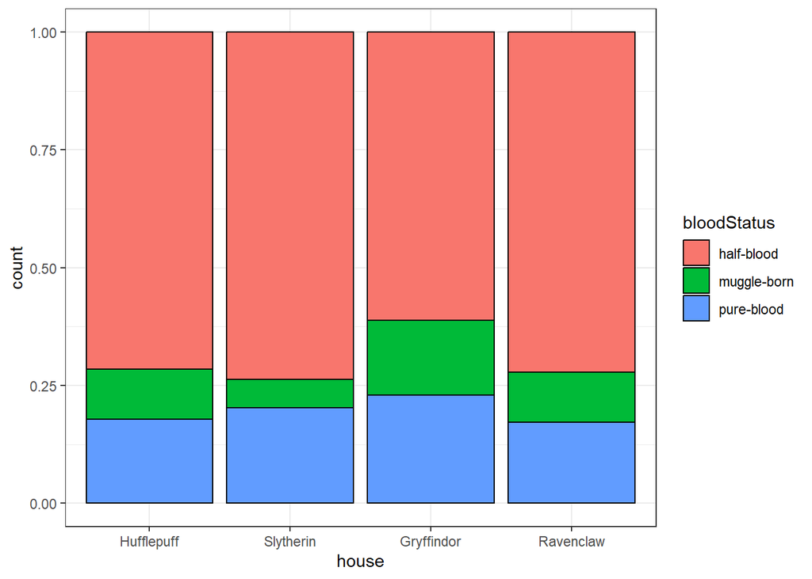

```r
ggplot(hogwarts)+
  geom_bar(aes(x = fct_infreq(house),
               fill = bloodStatus),
           position = "fill",
           colour = "black")+
  scale_x_discrete(name = "house")+
  theme_bw()
```

```r
?geom_bar()
```

```
## starting httpd help server ... done
```

По графику можно сделать вывод, что наибольшая доля полукровок от общего числа студентов приходится на Слизерин и Когтевран. Наибольшая доля маглорождённых от общего числа студентов факультета - на факультете Гриффиндор. Наибольшая доля чистокровных волшебников на факультетах Слизерин и Гриффиндор, причем на последнем эта доля немног больше. Доли студентов, прихододящиеся на каждую из категорий по статусу крови, примерно равны на Пуффендуе и Когтевране.